# ADMM nuclear

Charles Zheng

06/17/2015

Solve the following $\text{minimize } ||Y - F - XB||_F^2 + \lambda ||B||_1 + \eta ||F||_*^2 \text{ st }B_{ij} \geq 0$

```r
library(magrittr)
library(nnls)
library(parallel)
library(glmnet)
library(pracma)
n <- 30
p <- 40
v <- 30
X <- randn(n, p) %>% abs
B0 <- matrix(rexp(p * v), p, v)
F0 <- 10 * randn(n, 2) %*% randn(2, v)
E0 <- 0.1 * randn(n, v)
Y <- X %*% B0 + E0 + F0
f2 <- function(x) sum(x ^ 2)
nnorm <- function(x) sum(svd(x, nu = 0, nv = 0)$d)
rho <- 2 # used in ADMM later
lambda <- 0.01
nu <- 0.2
true_pars <- list(X = X, Y = Y, lambda = lambda, nu = nu, rho = rho,
             B = B0, E = E0,
             FF = F0, W = zeros(n, v))
```

# ADMM algorithm

Solve $\text{minimize } ||E||_F^2 + \lambda ||B||_1 + \eta ||F||_*^2$ subject to $B_{ij} \geq 0$ $Y = E + F + XB$

- Intitalize $W, B, F, E = 0$
- Iterate:
- $E = \text{argmin } ||E||_F^2 + \frac{\rho}{2} || E - (Y - XB - F - W)||_F^2$
- $B = \text{argmin } \lambda ||B||_1 + \frac{\rho}{2} || XB - (Y - E - F - W)||_F^2$
- $F = \text{argmin } \nu ||F||_*^2 + \frac{\rho}{2} || F - (Y - XB - E - W)||_F^2$
- $W = W - (Y - XB - E - F)$

```r
W <- zeros(n, v)
B <- zeros(p, v)
FF <- zeros(n, v)
E <- zeros(n, v)
```

#### Update $E$

$E = \text{argmin } ||E||_F^2 + \frac{\rho}{2} || E - (Y - XB - F - W)||_F^2$

given by

$E = \frac{\rho}{2 + \rho} (Y - XB - F - W)$

```r
objective_E <- function(W, B, FF, E) {
  f2(E) + (rho/2) * f2(E - (Y - X %*% B - FF - W))
}
update_E <- function(W, B, FF, E) {
  rho/(2 + rho) * (Y - X %*% B - FF - W)
}
E <- update_E(W, B, FF, E)
objective_E(W, B, FF, E)
```

```
## [1] 541397.8
```

```r
objective_E(W, B, FF, 1.01 * E)
```

```
## [1] 541451.9
```

```r
objective_E(W, B, FF, 0.99 * E)
```

```
## [1] 541451.9
```

#### Update $B$

$B = \text{argmin } \lambda ||B||_1 + \frac{\rho}{2} || XB - (Y - E - F - W)||_F^2$

equivalently

$B = \text{argmin } \frac{\lambda}{\rho} ||B||_1 + \frac{1}{2} || XB - (Y - E - F - W)||_F^2$

This is just nonnegative lasso with the response $Y - E - F - W$ and penalty $\lambda/\rho$

```r
objective_B <- function(W, B, FF, E) {
  lambda * sum(abs(B)) + (rho/2) * f2(E - (Y - X %*% B - FF - W))
}
lambda_nnls <- function(X, y, lambda, maxits = 5) {
  l1p <- 0
  for (i in 1:maxits) {
    b <- nnls(rbind(X, l1p), c(y, 0))$x
    if (sum(b) == 0) return(list(b = b, lambda = 0))
    l1p <- sqrt(lambda/sum(b))
  }
  list(b = b, lambda = l1p^2 * sum(b))
}
update_B <- function(W, B, FF, E) {
  R <- Y - E - FF - W
  do.call(cbind,
          mclapply(1:v,
          function(i)
            lambda_nnls(X, R[, i], lambda/rho)$b, mc.cores = 3))
}
B <- update_B(W, B, FF, E)
objective_B(W, B, FF, E)
```

```
## [1] 15512.32
```

```r
objective_B(W, B * 1.01, FF, E)
```

```
## [1] 15537.83
```

```r
objective_B(W, B * .99, FF, E)
```

```
## [1] 15537.83
```

#### Update $F$

$F = \text{argmin } \nu ||F||_*^2 + \frac{\rho}{2} || F - (Y - XB - E - W)||_F^2$

Take the SVD

$Y - XB - E - W = U\text{diag}(d_i)V^T$

Then $F$ takes the form

$F = U\text{diag}([d_i - t]_+)V^T.$

and

$\nu ||F||_*^2 + \frac{\rho}{2} || F - (Y - XB - E - W)||_F^2 = \nu \left(\sum [d_i - t]_+\right)^2 + \frac{\rho}{2}\sum \min(d_i, t)^2$

Search over $t$ to find the minimum.

```r
objective_F <- function(W, B, FF, E) {
  nu * nnorm(FF)^2 + (rho/2) * f2(E - (Y - X %*% B - FF - W))
}
soft <- function(x, tt) pmax(0, x - tt)
update_F <- function(W, B, FF, E) {
  R <- Y - X %*% B - E - W
  res <- svd(R)
  d <- res$d
  Ft <- function(tt) res$u %*% diag(soft(d, tt)) %*% t(res$v)
  objective_t <- function(tt) {
    nu * sum(soft(d, tt))^2 + (rho/2) * sum(pmin(tt, d)^2)
  }
  ts <- seq(0, max(d), max(d)/1000)
  vals <- sapply(ts, objective_t)
  tt <- ts[order(vals)[1]]
  Ft(tt)
}
FF <- update_F(W, B, FF, E)
objective_F(W, B, FF, E)
```

```
## [1] 5431.897
```

```r
objective_F(W, B, FF * 1.01, E)
```

```
## [1] 5432.913
```

```r
objective_F(W, B, FF * 0.99, E)
```

```
## [1] 5432.896
```

### Algorithm

```r
objective <- function(X, Y, lambda, nu, rho, B, FF, E, W, ...) {
  f2(Y - X %*% B - FF) + nu * nnorm(FF)^2 + lambda * sum(abs(B))
}

admm_iterate <- function(X, Y, lambda, nu, rho, B, FF, E, W,
                         mc.cores = 1, ...) {
  # Update B
  R <- Y - E - FF - W
  B <- do.call(cbind,
          mclapply(1:v,
          function(i)
            lambda_nnls(X, R[, i], lambda/rho)$b, mc.cores = mc.cores))
  XB <- X %*% B
  # Update FF
  R <- Y - XB - E - W
  res <- svd(R)
  d <- res$d
  objective_t <- function(tt) {
    nu * sum(soft(d, tt))^2 + (rho/2) * sum(pmin(tt, d)^2)
  }
  ts <- seq(0, max(d), max(d)/1000)
  vals <- sapply(ts, objective_t)
  tt <- ts[order(vals)[1]]
  FF <- res$u %*% diag(soft(d, tt)) %*% t(res$v)
  # Update E
  E <- rho/(2 + rho) * (Y - XB - FF - W)
  # Update W
  W <- W - (Y - XB - FF - E)
  list(X = X, Y = Y, lambda = lambda, nu = nu, rho = rho,
       B = B, FF = FF, E = E, W = W)
}

admm_nuclear <- function(X, Y, lambda, nu, rho, B, FF, E, W,
                         mc.cores = 1, maxits = 10, ...) {
  pars <- list(X = X, Y = Y, lambda = lambda, nu = nu, rho = rho,
               B = B, FF = FF, E = E, W = W, mc.cores = mc.cores)
  objs <- numeric(maxits)
  feas <- numeric(maxits)
  for (i in 1:maxits) {
    pars <- do.call(admm_iterate, pars)
    objs[i] <- do.call(objective, pars)
    feas[i] <- f2(Y - X %*% B - E - FF)
  }
  c(pars, list(objs = objs, feas = feas))
}
```

Apply the algorithm

```r
(ot <- do.call(objective, true_pars))
```

```
## [1] 49843.05
```

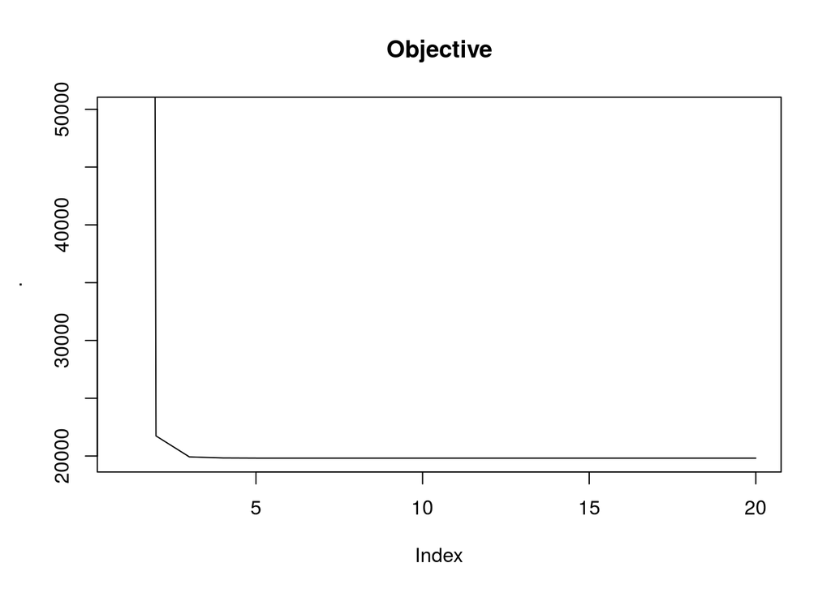

```r
pars <- list(X = X, Y = Y, lambda = lambda, nu = nu, rho = rho,
             B = zeros(p, v), E = Y,
             FF = zeros(n, v), W = zeros(n, v),
             mc.cores = 3, maxits = 20)
res <- do.call(admm_nuclear, pars)

res$objs %>% { plot(., main = "Objective", type = "l", ylim = c(min(.), ot)) }
```

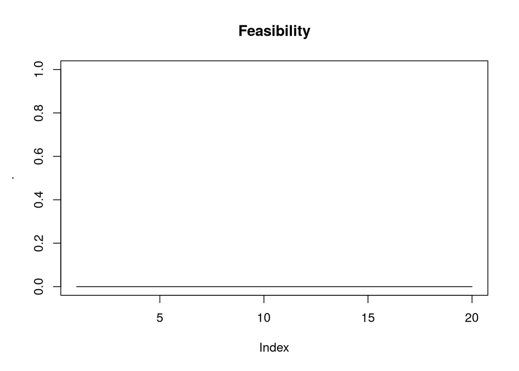

```r
res$feas %>% { plot(., main = "Feasibility", type = "l", ylim = c(0, max(1, median(.)))) }
```

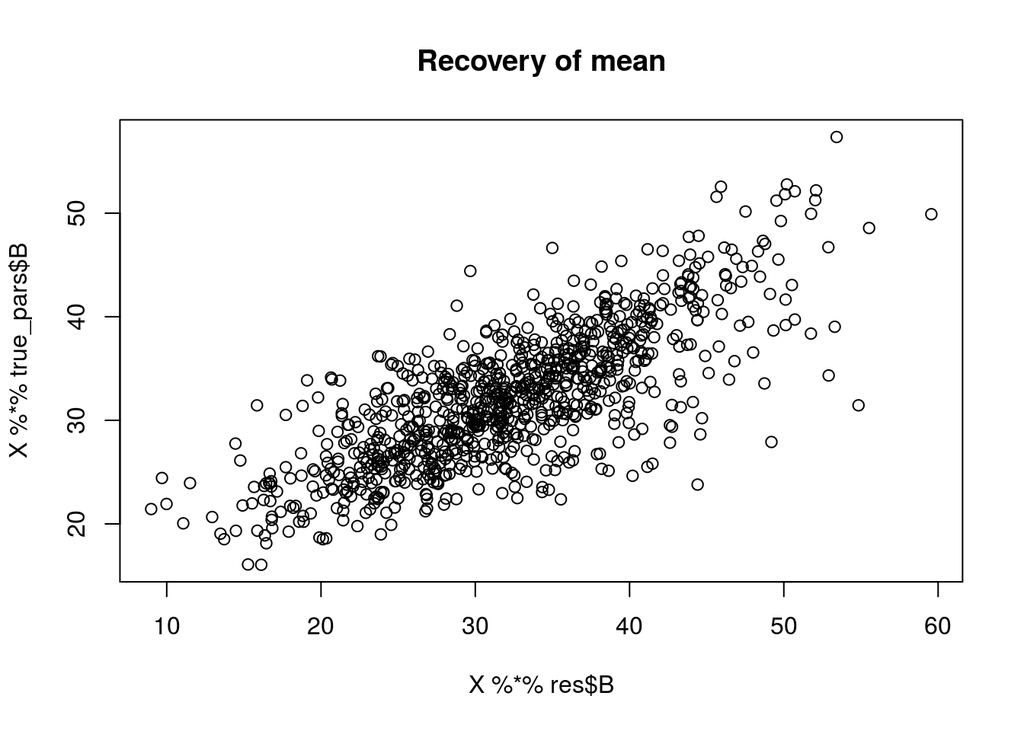

```r
plot(X %*% res$B, X %*% true_pars$B, main = "Recovery of mean")
```

```r
do.call(objective, res)
```

```
## [1] 19818.93
```